# Mbaaoum_Classification and Hypothesis Testing

## Context

The EdTech industry has been surging in the past decade immensely, and according to a forecast, the Online Education market would be worth $286.62bn by 2023 with a compound annual growth rate (CAGR) of 10.26% from 2018 to 2023. The modern era of online education has enforced a lot in its growth and expansion beyond any limit. Due to having many dominant features like ease of information sharing, personalized learning experience, transparency of assessment, etc, it is now preferable to traditional education.

In the present scenario due to the Covid-19, the online education sector has witnessed rapid growth and is attracting a lot of new customers. Due to this rapid growth, many new companies have emerged in this industry. With the availability and ease of use of digital marketing resources, companies can reach out to a wider audience with their offerings. The customers who show interest in these offerings are termed as leads. There are various sources of obtaining leads for Edtech companies, like

- The customer interacts with the marketing front on social media or other online platforms.
- The customer browses the website/app and downloads the brochure
- The customer connects through emails for more information.

The company then nurtures these leads and tries to convert them to paid customers. For this, the representative from the organization connects with the lead on call or through email to share further details.

## Objective

ExtraaLearn is an initial stage startup that offers programs on cutting-edge technologies to students and professionals to help them upskill/reskill. With a large number of leads being generated on a regular basis, one of the issues faced by ExtraaLearn is to identify which of the leads are more likely to convert so that they can allocate resources accordingly. You, as a data scientist at ExtraaLearn, have been provided the leads data to:

- Analyze and build an ML model to help identify which leads are more likely to convert to paid customers,
- Find the factors driving the lead conversion process
- Create a profile of the leads which are likely to convert

## Data Description

The data contains the different attributes of leads and their interaction details with ExtraaLearn. The detailed data dictionary is given below.

**Data Dictionary**

- ID: ID of the lead
- age: Age of the lead
- current_occupation: Current occupation of the lead. Values include 'Professional','Unemployed',and 'Student'
- first_interaction: How did the lead first interacted with ExtraaLearn. Values include 'Website', 'Mobile App'
- profile_completed: What percentage of profile has been filled by the lead on the website/mobile app. Values include Low - (0-50%), Medium - (50-75%), High (75-100%)
- website_visits: How many times has a lead visited the website
- time_spent_on_website: Total time spent on the website
- page_views_per_visit: Average number of pages on the website viewed during the visits.
- last_activity: Last interaction between the lead and ExtraaLearn.
  - Email Activity: Seeking for details about program through email, Representative shared information with lead like brochure of program , etc
  - Phone Activity: Had a Phone Conversation with representative, Had conversation over SMS with representative, etc
  - Website Activity: Interacted on live chat with representative, Updated profile on website, etc
- print_media_type1: Flag indicating whether the lead had seen the ad of ExtraaLearn in the Newspaper.
- print_media_type2: Flag indicating whether the lead had seen the ad of ExtraaLearn in the Magazine.
- digital_media: Flag indicating whether the lead had seen the ad of ExtraaLearn on the digital platforms.
- educational_channels: Flag indicating whether the lead had heard about ExtraaLearn in the education channels like online forums, discussion threads, educational websites, etc.
- referral: Flag indicating whether the lead had heard about ExtraaLearn through reference.
- status: Flag indicating whether the lead was converted to a paid customer or not.

## Importing necessary libraries and data

```python
import numpy as np
import pandas as pd
import matplotlib.pyplot as plt
import seaborn as sns
```

```python
from google.colab import drive
drive.mount('/content/drive')
```

```python
df = pd.read_csv('/content/drive/MyDrive/Python course/ 2nd Project MIT/ExtraaLearn.csv')
```

## Data Overview

- Observations
- Sanity checks

```python
rows, columns = df.shape
print(f'The data has {rows} rows and {columns} columns.')
```

```
The data has 4612 rows and 15 columns.
```

```python
df.head()
```

|  | ID | age | current_occupation | first_interaction | profile_completed | website_visits | time_spent_on_website | page_views_per_visit | last_activity | print_media_type1 | print_media_type2 | digital_media | educational_channels | referral | status |
| --- | --- | --- | --- | --- | --- | --- | --- | --- | --- | --- | --- | --- | --- | --- | --- |
| 0 | EXT001 | 57 | Unemployed | Website | High | 7 | 1639 | 1.861 | Website Activity | Yes | No | Yes | No | No | 1 |
| 1 | EXT002 | 56 | Professional | Mobile App | Medium | 2 | 83 | 0.320 | Website Activity | No | No | No | Yes | No | 0 |
| 2 | EXT003 | 52 | Professional | Website | Medium | 3 | 330 | 0.074 | Website Activity | No | No | Yes | No | No | 0 |
| 3 | EXT004 | 53 | Unemployed | Website | High | 4 | 464 | 2.057 | Website Activity | No | No | No | No | No | 1 |
| 4 | EXT005 | 23 | Student | Website | High | 4 | 600 | 16.914 | Email Activity | No | No | No | No | No | 0 |

```python
df.tail()
```

|  | ID | age | current_occupation | first_interaction | profile_completed | website_visits | time_spent_on_website | page_views_per_visit | last_activity | print_media_type1 | print_media_type2 | digital_media | educational_channels | referral | status |
| --- | --- | --- | --- | --- | --- | --- | --- | --- | --- | --- | --- | --- | --- | --- | --- |
| 4607 | EXT4608 | 35 | Unemployed | Mobile App | Medium | 15 | 360 | 2.170 | Phone Activity | No | No | No | Yes | No | 0 |
| 4608 | EXT4609 | 55 | Professional | Mobile App | Medium | 8 | 2327 | 5.393 | Email Activity | No | No | No | No | No | 0 |
| 4609 | EXT4610 | 58 | Professional | Website | High | 2 | 212 | 2.692 | Email Activity | No | No | No | No | No | 1 |
| 4610 | EXT4611 | 57 | Professional | Mobile App | Medium | 1 | 154 | 3.879 | Website Activity | Yes | No | No | No | No | 0 |
| 4611 | EXT4612 | 55 | Professional | Website | Medium | 4 | 2290 | 2.075 | Phone Activity | No | No | No | No | No | 0 |

```python
df.info()
```

```
<class 'pandas.core.frame.DataFrame'>
RangeIndex: 4612 entries, 0 to 4611
Data columns (total 15 columns):
 #   Column                 Non-Null Count  Dtype
---  ------                 --------------  -----
 0   ID                     4612 non-null   object
 1   age                    4612 non-null   int64
 2   current_occupation     4612 non-null   object
 3   first_interaction      4612 non-null   object
 4   profile_completed      4612 non-null   object
 5   website_visits         4612 non-null   int64
 6   time_spent_on_website  4612 non-null   int64
 7   page_views_per_visit   4612 non-null   float64
 8   last_activity          4612 non-null   object
 9   print_media_type1      4612 non-null   object
 10  print_media_type2      4612 non-null   object
 11  digital_media          4612 non-null   object
 12  educational_channels   4612 non-null   object
 13  referral               4612 non-null   object
 14  status                 4612 non-null   int64
dtypes: float64(1), int64(4), object(10)
memory usage: 540.6+ KB
```

**Comment:** The dataset contains 4612 entries with 15 columns. There are no missing values in the dataset, indicating that the data is complete. The dataset includes a mix of numerical and categorical variables. Numerical columns include age, website_visits, time_spent_on_website, and page_views_per_visit. Categorical columns include current_occupation, first_interaction, profile_completed, last_activity, print_media_type1, print_media_type2, digital_media, educational_channels, and referral

## Exploratory Data Analysis (EDA)

- EDA is an important part of any project involving data.
- It is important to investigate and understand the data better before building a model with it.
- A few questions have been mentioned below which will help you approach the analysis in the right manner and generate insights from the data.
- A thorough analysis of the data, in addition to the questions mentioned below, should be done.

**Questions**

1. Leads will have different expectations from the outcome of the course and the current occupation may play a key role in getting them to participate in the program. Find out how current occupation affects lead status.
2. The company's first impression on the customer must have an impact. Do the first channels of interaction have an impact on the lead status?
3. The company uses multiple modes to interact with prospects. Which way of interaction works best?
4. The company gets leads from various channels such as print media, digital media, referrals, etc. Which of these channels have the highest lead conversion rate?
5. People browsing the website or mobile application are generally required to create a profile by sharing their personal data before they can access additional information.Does having more details about a prospect increase the chances of conversion?

## Data Preprocessing

- Missing value treatment (if needed)
- Feature engineering (if needed)
- Outlier detection and treatment (if needed)
- Preparing data for modeling
- Any other preprocessing steps (if needed)

```python
missing_values = df.isnull().sum()
print("Missing values in each column:\n", missing_values)
```

```
Missing values in each column:
 ID                       0
age                      0
current_occupation       0
first_interaction        0
profile_completed        0
website_visits           0
time_spent_on_website    0
page_views_per_visit     0
last_activity            0
print_media_type1        0
print_media_type2        0
digital_media            0
educational_channels     0
referral                 0
status                   0
dtype: int64
```

```python
df.describe(include='all').T
```

|  | count | unique | top | freq | mean | std | min | 25% | 50% | 75% | max |
| --- | --- | --- | --- | --- | --- | --- | --- | --- | --- | --- | --- |
| ID | 4612 | 4612 | EXT001 | 1 | NaN | NaN | NaN | NaN | NaN | NaN | NaN |
| age | 4612.0 | NaN | NaN | NaN | 46.201214 | 13.161454 | 18.0 | 36.0 | 51.0 | 57.0 | 63.0 |
| current_occupation | 4612 | 3 | Professional | 2616 | NaN | NaN | NaN | NaN | NaN | NaN | NaN |
| first_interaction | 4612 | 2 | Website | 2542 | NaN | NaN | NaN | NaN | NaN | NaN | NaN |
| profile_completed | 4612 | 3 | High | 2264 | NaN | NaN | NaN | NaN | NaN | NaN | NaN |
| website_visits | 4612.0 | NaN | NaN | NaN | 3.566782 | 2.829134 | 0.0 | 2.0 | 3.0 | 5.0 | 30.0 |
| time_spent_on_website | 4612.0 | NaN | NaN | NaN | 724.011275 | 743.828683 | 0.0 | 148.75 | 376.0 | 1336.75 | 2537.0 |
| page_views_per_visit | 4612.0 | NaN | NaN | NaN | 3.026126 | 1.968125 | 0.0 | 2.07775 | 2.792 | 3.75625 | 18.434 |
| last_activity | 4612 | 3 | Email Activity | 2278 | NaN | NaN | NaN | NaN | NaN | NaN | NaN |
| print_media_type1 | 4612 | 2 | No | 4115 | NaN | NaN | NaN | NaN | NaN | NaN | NaN |
| print_media_type2 | 4612 | 2 | No | 4379 | NaN | NaN | NaN | NaN | NaN | NaN | NaN |
| digital_media | 4612 | 2 | No | 4085 | NaN | NaN | NaN | NaN | NaN | NaN | NaN |
| educational_channels | 4612 | 2 | No | 3907 | NaN | NaN | NaN | NaN | NaN | NaN | NaN |
| referral | 4612 | 2 | No | 4519 | NaN | NaN | NaN | NaN | NaN | NaN | NaN |
| status | 4612.0 | NaN | NaN | NaN | 0.298569 | 0.45768 | 0.0 | 0.0 | 0.0 | 1.0 | 1.0 |

- ID: Each entry has a unique ID, ensuring there are no duplicates.
- Age: The average age of the leads is approximately 46 years, with a range from 18 to 63 years.
- Current Occupation: Most leads are professionals (2616 out of 4612).
- First Interaction: The majority of leads first interacted through the website (2542 out of 4612).
- Profile Completed: Most profiles have a high completion rate (2264 out of 4612).
- Website Visits: On average, leads visited the website about 3.57 times.
- Time Spent on Website: Leads spent an average of 724 seconds on the website, with a wide range from 0 to 2537 seconds.
- Page Views per Visit: On average, leads viewed about 3 pages per visit.
- Last Activity: Email activity is the most common last activity (2278 out of 4612).
- Print Media Type 1 & 2: The majority of leads did not see ads in newspapers or magazines.
- Digital Media: Most leads did not see ads on digital platforms.
- Educational Channels: The majority of leads did not hear about ExtraaLearn through educational channels.
- Referral: Most leads were not referred by someone.
- Status: About 29.86% of leads converted to paid customers.

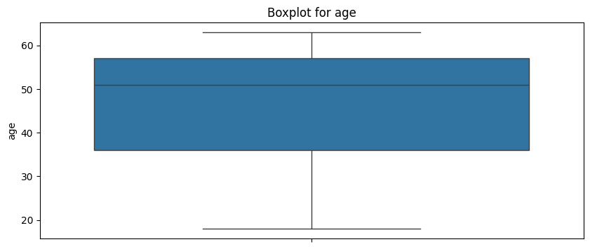

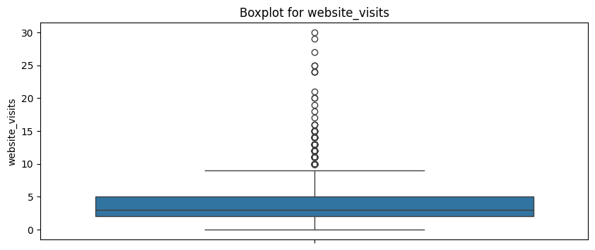

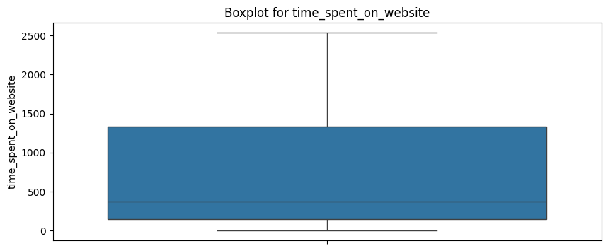

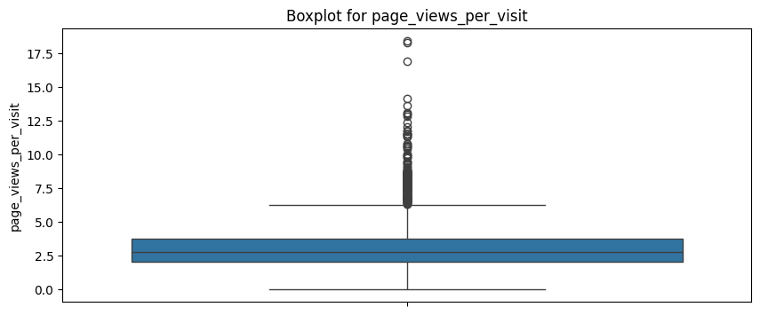

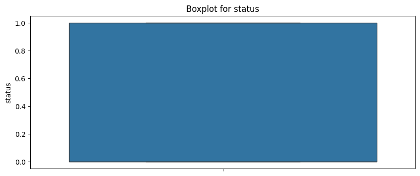

```python
# Outlier Detection and Treatment
# Visualize the numerical columns to identify outliers

numerical_cols = df.select_dtypes(include=[np.number]).columns

for col in numerical_cols:
    plt.figure(figsize=(10, 4))
    sns.boxplot(df[col])
    plt.title(f'Boxplot for {col}')
    plt.show()
```

```python
# To handle outliers, I will use the IQR method to cap the values
for col in numerical_cols:
    Q1 = df[col].quantile(0.25)
    Q3 = df[col].quantile(0.75)
    IQR = Q3 - Q1
    lower_bound = Q1 - 1.5 * IQR
    upper_bound = Q3 + 1.5 * IQR
    df[col] = np.where(df[col] < lower_bound, lower_bound, df[col])
    df[col] = np.where(df[col] > upper_bound, upper_bound, df[col])
```

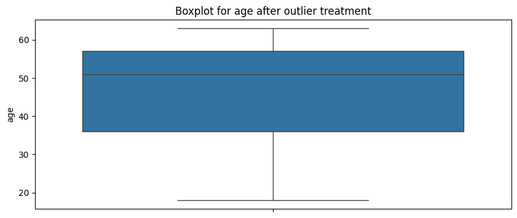

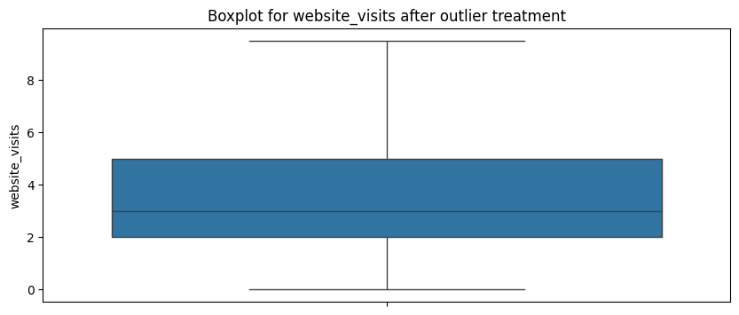

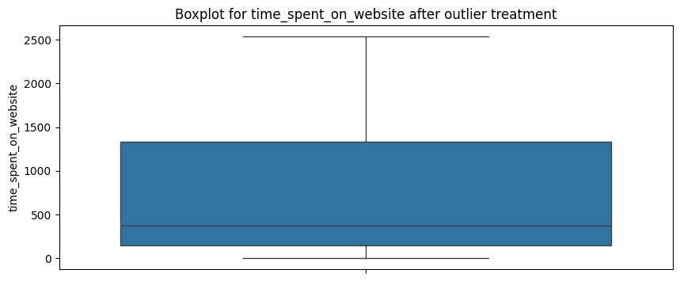

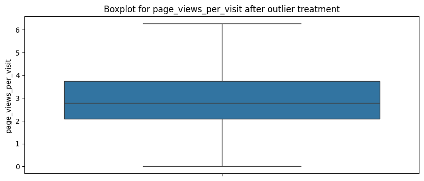

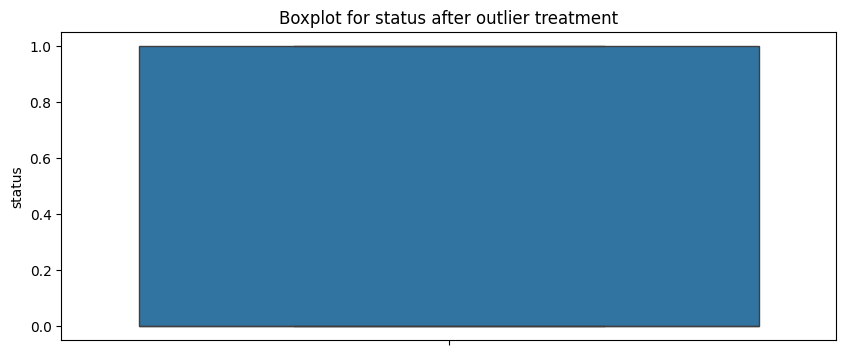

```python
# Verify that outliers are capped
for col in numerical_cols:
    plt.figure(figsize=(10, 4))
    sns.boxplot(df[col])
    plt.title(f'Boxplot for {col} after outlier treatment')
    plt.show()
```

## EDA

- It is a good idea to explore the data once again after manipulating it.

```python
# Check the column names after one-hot encoding
print(df.columns)
```

[output not shown]

There is a need to do feature engineering before building the model. I will perfomre this task after completing the EDA step

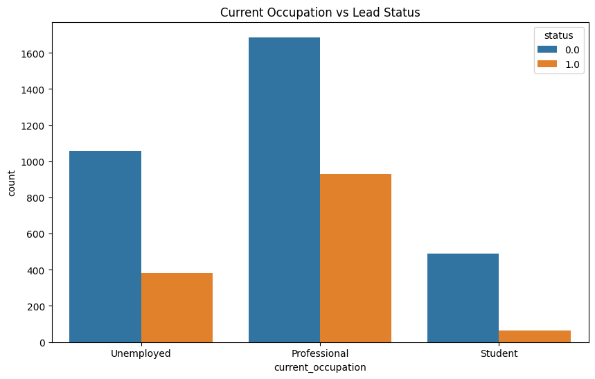

```python
# Question 1: Current occupation and lead status
plt.figure(figsize=(10, 6))
sns.countplot(data=df, x='current_occupation', hue='status')
plt.title('Current Occupation vs Lead Status')
plt.show()
```

**Comment:** Professionals have the highest conversion rate among the different occupation categories, followed by unemployed leads. Students have the lowest conversion rate. This indicates that professionals are more likely to be interested and have the resources to invest in upskilling or reskilling programs.

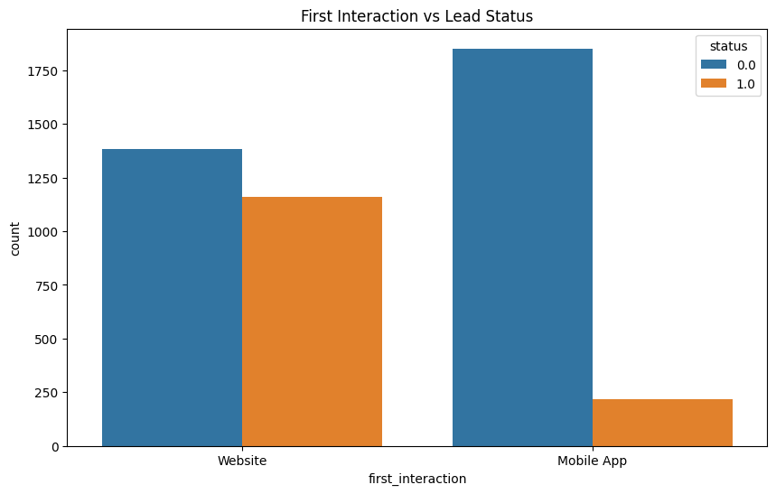

```python
# Question 2: First interaction and lead status
plt.figure(figsize=(10, 6))
sns.countplot(data=df, x='first_interaction', hue='status')
plt.title('First Interaction vs Lead Status')
plt.show()
```

**Comment:** Leads who first interacted through the website have a higher conversion rate compared to those who interacted through the mobile app. This suggests that website interactions might be more effective in conveying information and engaging potential leads.

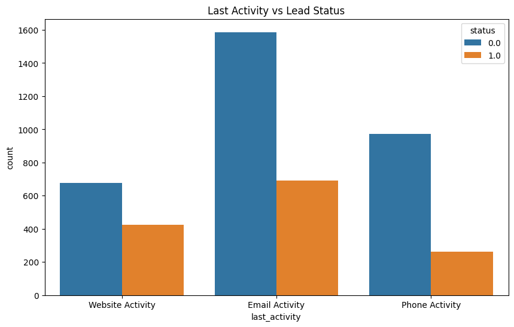

```python
# Question 3: Last activity and lead status
plt.figure(figsize=(10, 6))
sns.countplot(data=df, x='last_activity', hue='status')
plt.title('Last Activity vs Lead Status')
plt.show()
```

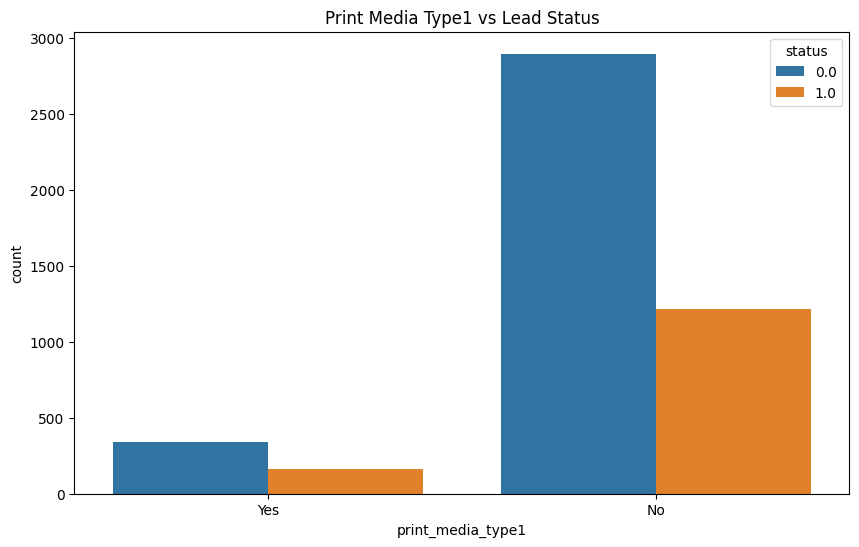

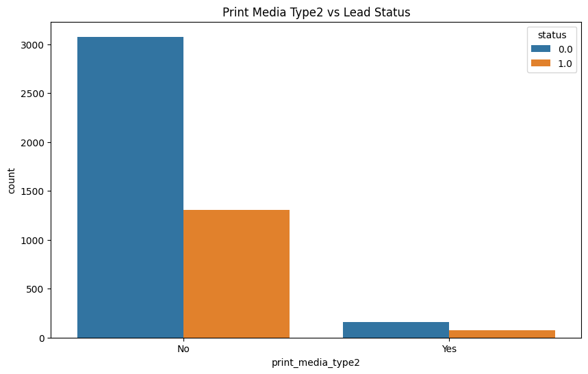

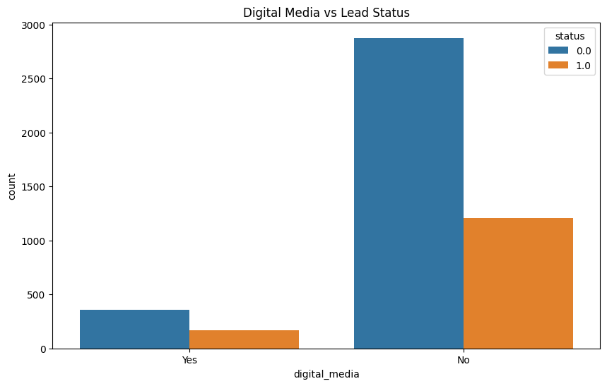

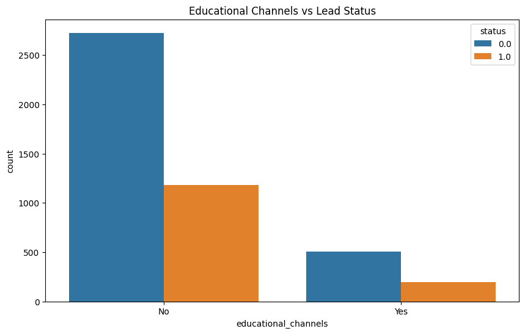

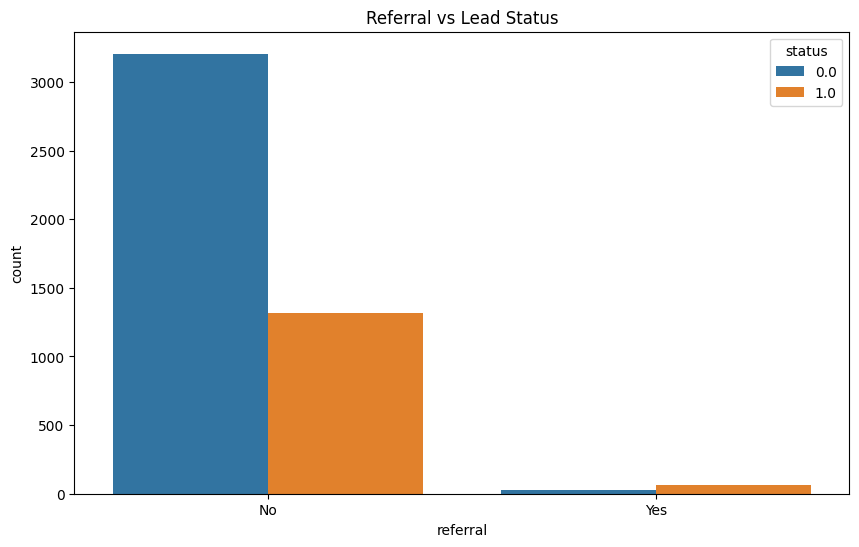

```python
# Question 4: Conversion rate by channels
channels = ['print_media_type1', 'print_media_type2', 'digital_media', 'educational_channels', 'referral']
for channel in channels:
    plt.figure(figsize=(10, 6))
    sns.countplot(data=df, x=channel, hue='status')
    plt.title(f'{channel.replace("_", " ").title()} vs Lead Status')
    plt.show()
```

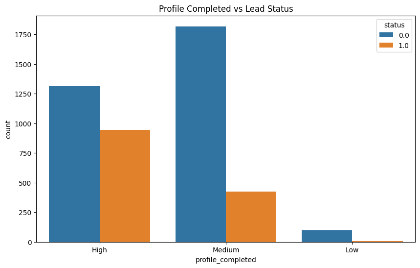

```python
# Question 5: Profile completeness and conversion rates
plt.figure(figsize=(10, 6))
sns.countplot(data=df, x='profile_completed', hue='status')
plt.title('Profile Completed vs Lead Status')
plt.show()
```

**Comment:** Leads with higher profile completion rates (medium and high) have significantly higher conversion rates compared to those with low profile completion. This indicates that encouraging leads to complete their profiles can significantly improve conversion rates.

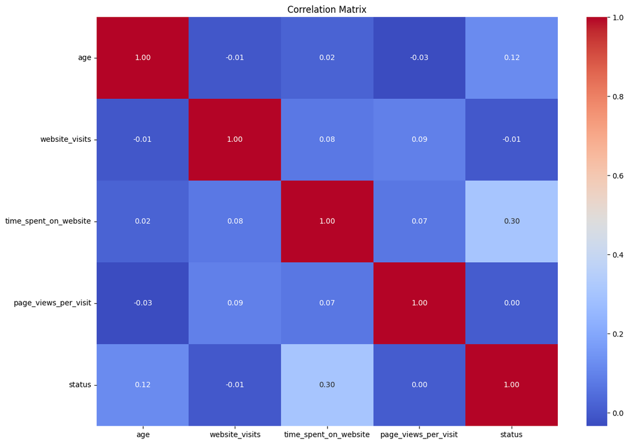

```python
# Additional EDA: Correlation matrix
# Select only the numeric columns for the correlation matrix
numeric_cols = df.select_dtypes(include=[np.number])

# Additional EDA: Correlation matrix
plt.figure(figsize=(14, 10))
sns.heatmap(numeric_cols.corr(), annot=True, fmt=".2f", cmap='coolwarm')
plt.title('Correlation Matrix')
plt.show()
```

**Comment:** Age has a weak positive correlation with status (0.12), suggesting older leads are slightly more likely to convert. Time spent on the website has a moderate positive correlation with status (0.30), indicating leads who spend more time are more likely to convert. Website visits and page views per visit show almost no correlation with status, suggesting these factors do not significantly impact lead conversion. Overall, time spent on the website appears to be the most indicative of lead conversion likelihood among the analyzed features.

## Building a Decision Tree model

```python
# Import necessary libraries for the Decision Tree model
from sklearn.model_selection import train_test_split
from sklearn.tree import DecisionTreeClassifier
from sklearn.metrics import classification_report, confusion_matrix, accuracy_score
```

```python
# Feature Engineering

# Perform one-hot encoding for categorical variables
df_encoded = pd.get_dummies(df, drop_first=True)

# Display the first few rows to verify
df_encoded.head()
```

|  | age | website_visits | time_spent_on_website | page_views_per_visit | status | ID_EXT002 | ID_EXT003 | ID_EXT004 | ID_EXT005 | ID_EXT006 | ... | first_interaction_Website | profile_completed_Low | profile_completed_Medium | last_activity_Phone Activity | last_activity_Website Activity | print_media_type1_Yes | print_media_type2_Yes | digital_media_Yes | educational_channels_Yes | referral_Yes |
| --- | --- | --- | --- | --- | --- | --- | --- | --- | --- | --- | --- | --- | --- | --- | --- | --- | --- | --- | --- | --- | --- |
| 0 | 57.0 | 7.0 | 1639.0 | 1.861 | 1.0 | False | False | False | False | False | ... | True | False | False | False | True | True | False | True | False | False |
| 1 | 56.0 | 2.0 | 83.0 | 0.320 | 0.0 | True | False | False | False | False | ... | False | False | True | False | True | False | False | False | True | False |
| 2 | 52.0 | 3.0 | 330.0 | 0.074 | 0.0 | False | True | False | False | False | ... | True | False | True | False | True | False | False | True | False | False |
| 3 | 53.0 | 4.0 | 464.0 | 2.057 | 1.0 | False | False | True | False | False | ... | True | False | False | False | True | False | False | False | False | False |
| 4 | 23.0 | 4.0 | 600.0 | 6.274 | 0.0 | False | False | False | True | False | ... | True | False | False | False | False | False | False | False | False | False |

5 rows × 4628 columns

```python
# Define the feature columns and target variable
X = df_encoded.drop('status', axis=1)
y = df_encoded['status']

# Split the data into training and testing sets
X_train, X_test, y_train, y_test = train_test_split(X, y, test_size=0.3, random_state=42)

# Initialize the Decision Tree Classifier
dt_model = DecisionTreeClassifier(random_state=42)

# Train the model
dt_model.fit(X_train, y_train)

# Make predictions
y_pred = dt_model.predict(X_test)

# Evaluate the model
print("Confusion Matrix:")
print(confusion_matrix(y_test, y_pred))

print("\nClassification Report:")
print(classification_report(y_test, y_pred))

print("\nAccuracy Score:")
print(accuracy_score(y_test, y_pred))
```

```
Confusion Matrix:
[[891  86]
 [127 280]]

Classification Report:
              precision    recall  f1-score   support

         0.0       0.88      0.91      0.89       977
         1.0       0.77      0.69      0.72       407

    accuracy                           0.85      1384
   macro avg       0.82      0.80      0.81      1384
weighted avg       0.84      0.85      0.84      1384


Accuracy Score:
0.8460982658959537
```

**Comment:** Decision Tree Model Evaluation

The model shows a high accuracy of 84.61%, indicating good overall performance. Precision and recall are higher for non-converted leads, suggesting the model is better at identifying leads that do not convert. The model has room for improvement in predicting converted leads, as indicated by the lower precision and recall for class 1.

## Do we need to prune the tree?

```python
# Initialize the Decision Tree Classifier with max_depth for pruning
dt_model_pruned = DecisionTreeClassifier(max_depth=5, random_state=42)
```

```python
# Train the pruned model
dt_model_pruned.fit(X_train, y_train)

# Make predictions with the pruned model
y_pred_pruned = dt_model_pruned.predict(X_test)

# Evaluate the pruned model
print("Confusion Matrix (Pruned):")
print(confusion_matrix(y_test, y_pred_pruned))

print("\nClassification Report (Pruned):")
print(classification_report(y_test, y_pred_pruned))

print("\nAccuracy Score (Pruned):")
print(accuracy_score(y_test, y_pred_pruned))
```

```
Confusion Matrix (Pruned):
[[873 104]
 [100 307]]

Classification Report (Pruned):
              precision    recall  f1-score   support

         0.0       0.90      0.89      0.90       977
         1.0       0.75      0.75      0.75       407

    accuracy                           0.85      1384
   macro avg       0.82      0.82      0.82      1384
weighted avg       0.85      0.85      0.85      1384


Accuracy Score (Pruned):
0.8526011560693642
```

**Comment:** Pruned Decision Tree Model Evaluation

The pruned model maintains a high accuracy of 85.26%, similar to the unpruned model. Precision and recall for non-converted leads remain high, indicating consistent performance in identifying non-converted leads. The pruned model shows improved balance between precision and recall for converted leads, both at 0.75, suggesting better overall performance in predicting converted leads compared to the unpruned model. Pruning helps reduce model complexity while maintaining performance, making the model more generalizable.

## Building a Random Forest model

```python
from sklearn.ensemble import RandomForestClassifier
from sklearn.metrics import classification_report, confusion_matrix, accuracy_score
```

```python
# Initialize the Random Forest Classifier
rf_model = RandomForestClassifier(random_state=42)

# Train the model
rf_model.fit(X_train, y_train)

# Make predictions
y_pred_rf = rf_model.predict(X_test)

# Evaluate the model
print("Confusion Matrix (Random Forest):")
print(confusion_matrix(y_test, y_pred_rf))

print("\nClassification Report (Random Forest):")
print(classification_report(y_test, y_pred_rf))

print("\nAccuracy Score (Random Forest):")
print(accuracy_score(y_test, y_pred_rf))
```

```
Confusion Matrix (Random Forest):
[[935  42]
 [182 225]]

Classification Report (Random Forest):
              precision    recall  f1-score   support

         0.0       0.84      0.96      0.89       977
         1.0       0.84      0.55      0.67       407

    accuracy                           0.84      1384
   macro avg       0.84      0.75      0.78      1384
weighted avg       0.84      0.84      0.83      1384


Accuracy Score (Random Forest):
0.838150289017341
```

**Comment:** The Random Forest model achieved an accuracy of 83.82%, which is comparable to the Decision Tree models. Both precision and recall for non-converted leads are high, indicating the model effectively identifies non-converted leads. Precision for converted leads is high at 0.84, but recall is lower at 0.55, indicating some difficulty in identifying all converted leads. Overall, the Random Forest model provides a balanced performance with good precision but can improve in recall for converted leads.

## Do we need to prune the tree?

In the context of Random Forests, individual decision trees are typically not pruned as they are in standard decision tree models. The reason is that Random Forests inherently reduce overfitting by averaging multiple decision trees, each trained on different subsets of the data. This ensemble approach mitigates the need for pruning.

## Actionable Insights and Recommendations

- **Focus on Lead Engagement:**

  Time Spent on Website: Leads who spend more time on the website are more likely to convert. Ensure the website content is engaging, informative, and easy to navigate. Consider adding more interactive elements such as live chats, video demos, and testimonials to keep visitors engaged.
- **Optimize Marketing Channels:**
  - Digital Media and Referrals: The presence of digital media and referrals as channels indicates their importance. Strengthen digital marketing efforts on platforms where potential leads are most active. Encourage satisfied users to refer others by offering incentives or referral programs.
- **Improve Profile Completion Rates:**
  - Profile Completion: Leads with higher profile completion rates are more likely to convert. Simplify the profile completion process and provide clear benefits for completing profiles, such as personalized recommendations or exclusive content access.
- **Target Specific Occupations:**
- Current Occupation: Different occupations have varying conversion rates. Tailor marketing messages to resonate with each occupation group. For example, highlight career advancement for professionals and job readiness for students.
- **Personalized Follow-Ups:**
  - Last Activity: Understanding the last activity can help in personalizing follow-ups. For example, if a lead’s last activity was downloading a brochure, follow up with additional information and success stories related to the program.
- **Model Deployment and Monitoring:**
- Machine Learning Model: Deploy the pruned Decision Tree or Random Forest model in the lead management system to predict conversion likelihood. Regularly monitor and retrain the model with new data to maintain accuracy.
- **Resource Allocation:** Efficient Resource Allocation: Use the model’s predictions to allocate sales and marketing resources more efficiently. Focus efforts on leads with a higher likelihood of conversion to improve overall conversion rates. Feedback and Improvement:
- **Continuous Improvement:** Collect feedback from leads and customers to identify areas for improvement in the lead nurturing process. Then use this feedback to refine marketing strategies and improve user experience.

**Implementation Steps**

- **Engagement Enhancement:** Implement website enhancements to increase engagement time. Use A/B testing to determine the most effective content and layout.
- **Marketing Optimization:**

  Increase investment in digital marketing campaigns on high-performing platforms. Develop and promote a referral program.
- **Profile Completion:**

Simplify the profile completion process. Communicate the benefits of a complete profile to users.

- **Targeted Messaging:**

Develop occupation-specific marketing campaigns. Customize email follow-ups based on the lead’s last activity.

- **Model Deployment:**

Integrate the pruned Decision Tree or Random Forest model into the CRM system. Set up regular retraining schedules to update the model with new data.

- **Resource Allocation:**

Use model predictions to prioritize high-potential leads. Monitor conversion rates to adjust resource allocation strategies as needed.

```python
# Download the HTML file

!pip install nbconvert

import nbconvert
import os

notebook_filename = '/content/drive/MyDrive/Python course/ 2nd Project MIT/Mbaaoum_Classification and Hypothesis Testing.ipynb'

# Convert the .ipynb file to HTML
os.system(f'jupyter nbconvert --to html "{notebook_filename}"')

# Download the HTML file
html_filename = notebook_filename.replace('.ipynb', '.html')
from google.colab import files
files.download(html_filename)
```